# Recall performance for objects outside the rooms

# 1 Visual inspection of the data

```
## [1] "P17" "P54"
```

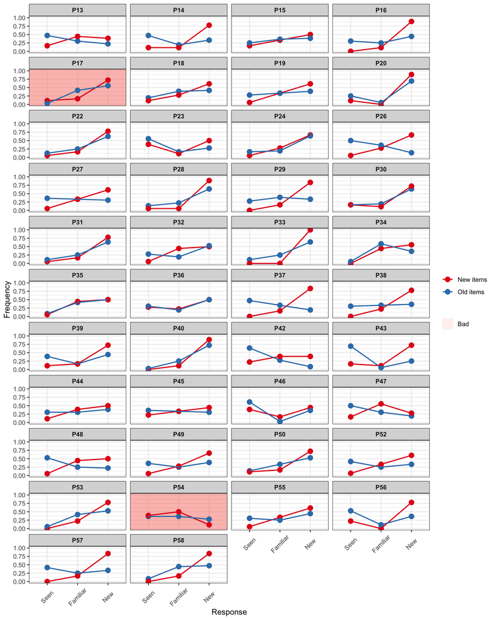

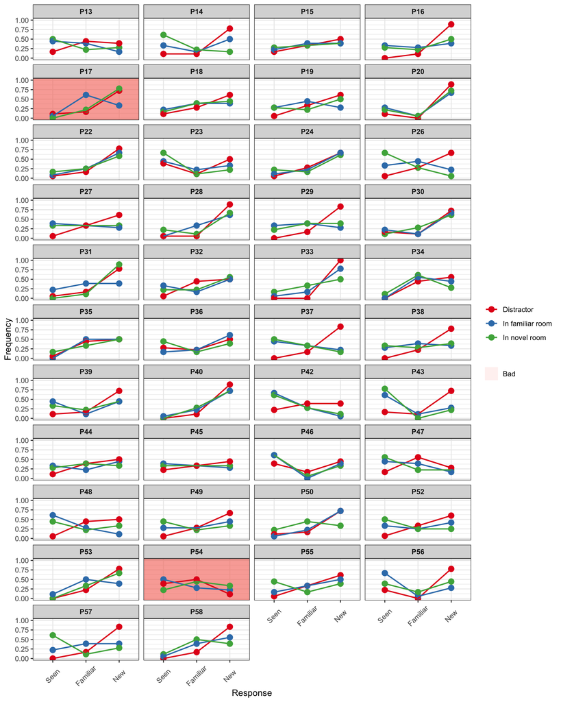

# 2 Novelty Benefits

## 2.1 Check the data

**Is there any corrected hit rate < 0?**

- There are 5 negative values out of a total of 80 values.

```
##    SubjectNo    Group MeanCurRt  MeanDur     SFHit       SHit    SrcHit
## 1:       P30    Novel  4.666667      NaN 0.3888889 0.11111111 0.1111111
## 2:       P31    Novel  6.000000      NaN 0.1111111 0.00000000 0.0000000
## 3:       P35 Familiar  3.000000      NaN 0.5000000 0.00000000 0.1666667
## 4:       P36 Familiar  5.000000      NaN 0.3888889 0.16666667 0.1111111
## 5:       P50 Familiar  2.000000 24.14499 0.2777778 0.05555556 0.1111111
##      SFFalse     SFalse   SrcFalse      SFAcc        SAcc      SrcAcc
## 1: 0.2777778 0.16666667 0.09259259  0.1111111 -0.05555556  0.01851852
## 2: 0.2222222 0.05555556 0.07407407 -0.1111111 -0.05555556 -0.07407407
## 3: 0.5000000 0.05555556 0.16666667  0.0000000 -0.05555556  0.00000000
## 4: 0.5000000 0.27777778 0.16666667 -0.1111111 -0.11111111 -0.05555556
## 5: 0.2777778 0.11111111 0.09259259  0.0000000 -0.05555556  0.01851852
```

## 2.2 Compare mean accuracy between *novel* and *familiar* rooms

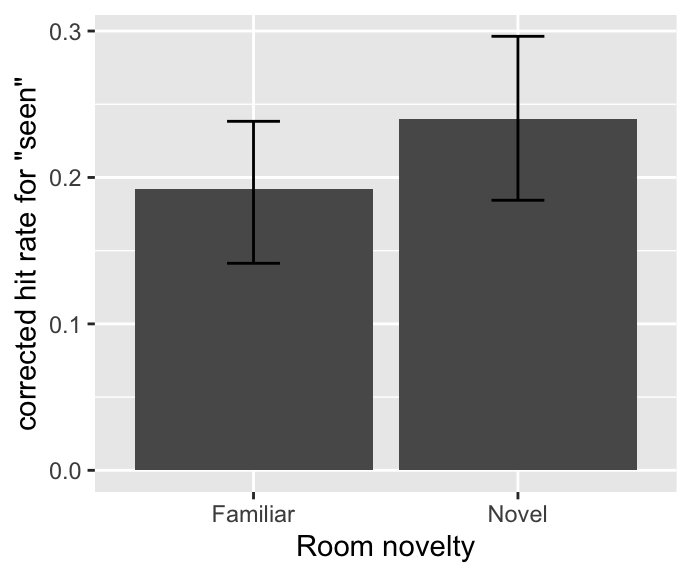

Figure1. Mean accuracy for item memory respectively for Familiar and Novel rooms.

```
##       Group      Mean        SD  N
## 1:    Novel 0.2400000 0.1764337 40
## 2: Familiar 0.1920833 0.1586679 40
```

```
##
##  Paired t-test
##
## data:  SAcc by Group
## t = -1.9619, df = 39, p-value = 0.05694
## alternative hypothesis: true difference in means is not equal to 0
## 95 percent confidence interval:
##  -0.097317455  0.001484121
## sample estimates:
## mean of the differences
##             -0.04791667
```

## 2.3 Any difference between *Early* and *Later* object groups?

### 2.3.1 Check the data

- **Is there any corrected hit rate < 0?**
  - There are 14 negative values out of a total of 160 values.

```
##     SubjectNo    Group ObjOrdGrp MeanCurRt  MeanDur     SFHit      SHit
##  1:       P22    Novel     Early  6.000000      NaN 0.1666667 0.0000000
##  2:       P22 Familiar     Later  2.500000      NaN 0.1666667 0.0000000
##  3:       P23 Familiar     Later  5.000000      NaN 0.4444444 0.2222222
##  4:       P28 Familiar     Later  1.333333      NaN 0.2222222 0.0000000
##  5:       P30    Novel     Early  4.666667      NaN 0.2222222 0.1111111
##  6:       P30    Novel     Later  4.666667      NaN 0.5555556 0.1111111
##  7:       P31    Novel     Later  6.000000      NaN 0.0000000 0.0000000
##  8:       P31    Novel     Early  6.000000      NaN 0.2222222 0.0000000
##  9:       P35 Familiar     Early  3.000000      NaN 0.5555556 0.0000000
## 10:       P35 Familiar     Later  3.000000      NaN 0.4444444 0.0000000
## 11:       P36 Familiar     Early  5.000000      NaN 0.3333333 0.2222222
## 12:       P36 Familiar     Later  5.000000      NaN 0.4444444 0.1111111
## 13:       P45    Novel     Later  6.000000 32.32439 0.4444444 0.1111111
## 14:       P50 Familiar     Later  2.000000 24.14499 0.2222222 0.0000000
```

[output cut: 30 more lines]

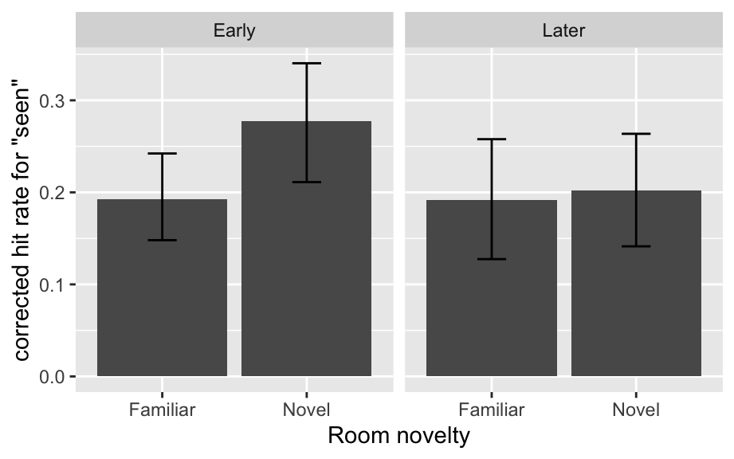

```
##       Group ObjOrdGrp      Mean        SD  N
## 1:    Novel     Early 0.2775000 0.2072673 40
## 2: Familiar     Later 0.1913889 0.2124115 40
## 3:    Novel     Later 0.2025000 0.2054572 40
## 4: Familiar     Early 0.1927778 0.1572869 40
```

```
## $ANOVA
##            Effect DFn DFd        F          p p<.05         ges
## 2           Group   1  39 3.849147 0.05693632       0.014962534
## 3       ObjOrdGrp   1  39 2.092683 0.15599593       0.009558907
## 4 Group:ObjOrdGrp   1  39 3.727366 0.06082138       0.008882417
```

# 3 Curiosity Enhancement

## 3.1 Check the data

### 3.1.1 Is there any corrected hit rate < 0?

#### 3.1.1.1 For the data per room

- There are 35 negative values out of a total of 236 values.

```
##     SubjectNo     Context    Group CurRating RoomOrder Duration     SFHit
##  1:       P15         Gym Familiar         4    Second       NA 0.5000000
##  2:       P15 StorageRoom    Novel         5     First       NA 0.3333333
##  3:       P18     Bedroom Familiar         2    Second       NA 0.6666667
##  4:       P18   Classroom Familiar         5    Second       NA 0.3333333
##  5:       P18  LivingRoom    Novel         7     First       NA 0.3333333
##  6:       P20   Classroom Familiar         4     First       NA 0.0000000
##  7:       P20     Library    Novel         2     First       NA 0.0000000
##  8:       P20 StorageRoom    Novel         6    Second       NA 0.1666667
##  9:       P22   Classroom    Novel         7    Second       NA 0.1666667
## 10:       P22     Library Familiar         2     First       NA 0.3333333
## 11:       P23     Library Familiar         4    Second       NA 0.5000000
## 12:       P23  LivingRoom Familiar         4    Second       NA 0.5000000
## 13:       P24     Bedroom    Novel         6    Second       NA 0.1666667
## 14:       P24     Library Familiar         2     First       NA 0.1666667
```

[output cut: 96 more lines]

#### 3.1.1.2 For the data per curiosity group

- There are 6 negative value for curiosity group (1 ~ 3 and 5 ~ 7) out of a total of 76 values.

```
##    SubjectNo CurGrp  MeanDur      SFHit       SHit     SrcHit   SFFalse
## 1:       P18   High      NaN 0.44444444 0.05555556 0.05555556 0.3888889
## 2:       P24    Low      NaN 0.08333333 0.00000000 0.08333333 0.3333333
## 3:       P31   High      NaN 0.11111111 0.00000000 0.00000000 0.2222222
## 4:       P35    Low      NaN 0.58333333 0.00000000 0.25000000 0.5000000
## 5:       P36    Low      NaN 0.33333333 0.00000000 0.16666667 0.5000000
## 6:       P50    Low 24.14499 0.27777778 0.05555556 0.11111111 0.2777778
##        SFalse   SrcFalse       SFAcc        SAcc       SrcAcc
## 1: 0.11111111 0.12962963  0.05555556 -0.05555556 -0.074074074
## 2: 0.05555556 0.07407407 -0.25000000 -0.05555556  0.009259259
## 3: 0.05555556 0.07407407 -0.11111111 -0.05555556 -0.074074074
## 4: 0.05555556 0.16666667  0.08333333 -0.05555556  0.083333333
## 5: 0.27777778 0.16666667 -0.16666667 -0.27777778  0.000000000
## 6: 0.11111111 0.09259259  0.00000000 -0.05555556  0.018518519
```

#### 3.1.1.3 For the data per curiosity group (median)

- There are 6 negative value for curiosity group (median) out of a total of 79 values.

```
##    SubjectNo CurGrpMedian  MeanDur     SFHit       SHit     SrcHit
## 1:       P18         High      NaN 0.4444444 0.05555556 0.05555556
## 2:       P30          Low      NaN 0.2500000 0.08333333 0.08333333
## 3:       P31         High      NaN 0.1111111 0.00000000 0.00000000
## 4:       P35          Low      NaN 0.5000000 0.00000000 0.16666667
## 5:       P36          Low      NaN 0.3888889 0.22222222 0.22222222
## 6:       P50          Low 24.14499 0.2777778 0.05555556 0.11111111
##      SFFalse     SFalse   SrcFalse       SFAcc        SAcc       SrcAcc
## 1: 0.3888889 0.11111111 0.12962963  0.05555556 -0.05555556 -0.074074074
## 2: 0.2777778 0.16666667 0.09259259 -0.02777778 -0.08333333 -0.009259259
## 3: 0.2222222 0.05555556 0.07407407 -0.11111111 -0.05555556 -0.074074074
## 4: 0.5000000 0.05555556 0.16666667  0.00000000 -0.05555556  0.000000000
## 5: 0.5000000 0.27777778 0.16666667 -0.11111111 -0.05555556  0.055555556
## 6: 0.2777778 0.11111111 0.09259259  0.00000000 -0.05555556  0.018518519
```

## 3.2 Mean accuracy of item memory as a function of curiosity rating

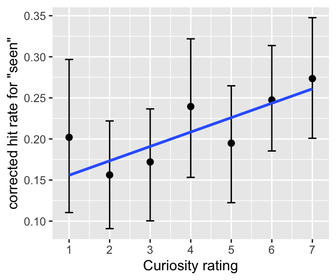

## 3.3 Testing the relationship between mean accuracy of item memory and curiosity rating

Build models with item memory accuracy as $y$ and examine effects of curiosity rating by including it into the model and then comparing the model fits.

- `baseline.rating` is the model with only an intercept, showing no change in item memory as a function of curiosity rating.
- `rating.intercept` is the model with $\small CuriosityRating$ included, showing the effects of curiosity rating.
- `rating.slope` is the model allowing the slope (i.e., relationship between item memory and curiosity rating) varying across participants.

```
##                  Model df       AIC       BIC   logLik   Test  L.Ratio
## baseline.rating      1  3 -72.33323 -61.94174 39.16662
## rating.intercept     2  4 -76.11358 -62.25826 42.05679 1 vs 2 5.780351
## rating.slope         3  6 -75.81401 -55.03102 43.90700 2 vs 3 3.700424
##                  p-value
## baseline.rating
## rating.intercept  0.0162
## rating.slope      0.1572
```

```
## Linear mixed-effects model fit by maximum likelihood
##  Data: outside.hit.rate.per.room
##         AIC       BIC logLik
##   -75.81401 -55.03102 43.907
##
## Random effects:
##  Formula: ~1 + CurRating | SubjectNo
##  Structure: General positive-definite, Log-Cholesky parametrization
##             StdDev     Corr
## (Intercept) 0.16486277 (Intr)
## CurRating   0.02905212 -0.657
## Residual    0.17171532
##
## Fixed effects: SAcc ~ CurRating
##                  Value  Std.Error  DF  t-value p-value
## (Intercept) 0.14111802 0.04035047 195 3.497308  0.0006
## CurRating   0.01592753 0.00786377 195 2.025431  0.0442
##  Correlation:
##           (Intr)
## CurRating -0.821
##
## Standardized Within-Group Residuals:
##        Min         Q1        Med         Q3        Max
## -2.0357002 -0.5907400 -0.0714542  0.6089378  2.5725758
##
## Number of Observations: 236
## Number of Groups: 40
```

## 3.4 Check the curiosity groups

### 3.4.1 Separate the groups according to the rating

- *High*: curiosity rating > 4
- *Low*: curiosity rating < 4
- For curiosity rating = 4, discarded

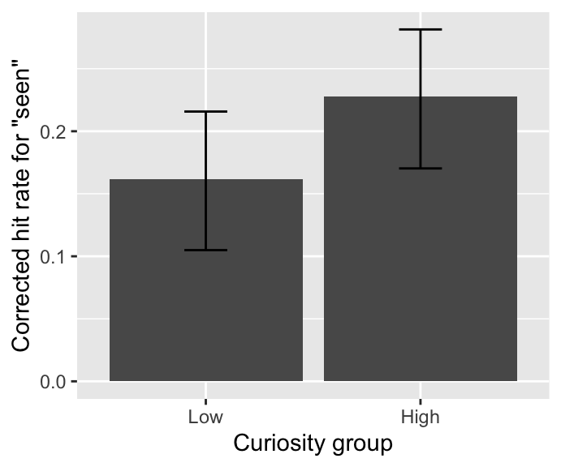

```
##    CurGrp      Mean        SD  N
## 1:   High 0.2279861 0.1768734 40
## 2:    Low 0.1617284 0.1699298 36
```

```
## Linear mixed-effects model fit by maximum likelihood
##  Data: outside.hit.rate.curiosity.group
##         AIC       BIC   logLik
##   -45.71588 -31.73148 28.85794
##
## Random effects:
##  Formula: ~1 + CurGrp | SubjectNo
##  Structure: General positive-definite, Log-Cholesky parametrization
##             StdDev    Corr
## (Intercept) 0.1524966 (Intr)
## CurGrpHigh  0.1650248 -0.494
## Residual    0.0699727
##
## Fixed effects: SAcc ~ CurGrp
##                  Value  Std.Error DF  t-value p-value
## (Intercept) 0.16223995 0.02814570 39 5.764289   0.000
## CurGrpHigh  0.06574616 0.03193791 35 2.058562   0.047
##  Correlation:
##            (Intr)
## CurGrpHigh -0.572
##
## Standardized Within-Group Residuals:
##          Min           Q1          Med           Q3          Max
## -1.090229029 -0.289259974 -0.006838212  0.275255463  1.016275933
##
## Number of Observations: 76
## Number of Groups: 40
```

#### 3.4.1.1 Curiosity groups and temporal order of the objects

##### 3.4.1.1.1 Check the data

- **Is there any corrected hit rate < 0?**
  - There are 28 negative values out of a total of 200 values.

```
##     SubjectNo CurGrp ObjOrdGrp     SFHit      SHit    SrcHit   SFFalse
##  1:       P14    Low     Later 0.3333333 0.0000000 0.3333333 0.2222222
##  2:       P15   <NA>     Early 0.1666667 0.0000000 0.1666667 0.5000000
##  3:       P15    Low     Later 0.6666667 0.0000000 0.6666667 0.5000000
##  4:       P18   High     Later 0.3333333 0.0000000 0.0000000 0.3888889
##  5:       P20   <NA>     Later 0.0000000 0.0000000 0.0000000 0.1111111
##  6:       P20   <NA>     Early 0.0000000 0.0000000 0.0000000 0.1111111
##  7:       P22   High     Early 0.1666667 0.0000000 0.0000000 0.2222222
##  8:       P22    Low     Later 0.1666667 0.0000000 0.0000000 0.2222222
##  9:       P23   <NA>     Later 0.1666667 0.0000000 0.1666667 0.5000000
## 10:       P24    Low     Early 0.0000000 0.0000000 0.0000000 0.3333333
## 11:       P24    Low     Later 0.1666667 0.0000000 0.1666667 0.3333333
## 12:       P27    Low     Later 0.5000000 0.0000000 0.3333333 0.3888889
## 13:       P28    Low     Later 0.2222222 0.0000000 0.1111111 0.1111111
## 14:       P30   <NA>     Later 0.3333333 0.0000000 0.1666667 0.2777778
```

[output cut: 45 more lines]

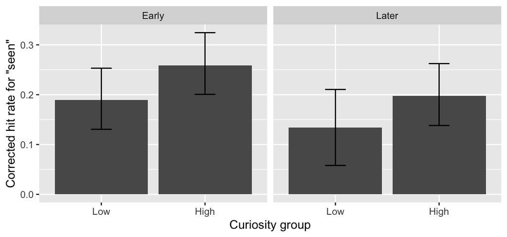

```
##    CurGrp ObjOrdGrp      Mean        SD  N
## 1:   High     Early 0.2587500 0.2026607 40
## 2:    Low     Later 0.1339506 0.2331737 36
## 3:   High     Later 0.1972222 0.2068355 40
## 4:    Low     Early 0.1895062 0.1913831 36
```

```
##           Model df       AIC       BIC   logLik   Test  L.Ratio p-value
## baseline      1  8 -43.61519 -19.42415 29.80760
## ord.model     2  9 -46.27464 -19.05971 32.13732 1 vs 2 4.659444  0.0309
## cur.model     3 10 -48.43099 -18.19219 34.21550 2 vs 3 4.156354  0.0415
## int.model     4 11 -46.44204 -13.17935 34.22102 3 vs 4 0.011044  0.9163
```

```
## Linear mixed-effects model fit by maximum likelihood
##  Data: outside.hit.rate.item.order.curiosity
##         AIC       BIC   logLik
##   -46.44204 -13.17935 34.22102
##
## Random effects:
##  Formula: ~1 + CurGrp + ObjOrdGrp | SubjectNo
##  Structure: General positive-definite, Log-Cholesky parametrization
##                StdDev     Corr
## (Intercept)    0.12067535 (Intr) CrGrpH
## CurGrpHigh     0.11773886 -0.508
## ObjOrdGrpLater 0.07782883  0.049  0.321
## Residual       0.15230987
##
## Fixed effects: SAcc ~ ObjOrdGrp + CurGrp + ObjOrdGrp:CurGrp
##                                 Value  Std.Error  DF   t-value p-value
## (Intercept)                0.19012134 0.03273869 109  5.807237  0.0000
## ObjOrdGrpLater            -0.05631257 0.03861785 109 -1.458201  0.1477
## CurGrpHigh                 0.06862866 0.04061377 109  1.689788  0.0939
## ObjOrdGrpLater:CurGrpHigh -0.00521520 0.05027004 109 -0.103744  0.9176
##  Correlation:
##                           (Intr) ObjOGL CrGrpH
## ObjOrdGrpLater            -0.517
## CurGrpHigh                -0.664  0.472
## ObjOrdGrpLater:CurGrpHigh  0.404 -0.688 -0.617
##
## Standardized Within-Group Residuals:
##        Min         Q1        Med         Q3        Max
## -1.6749504 -0.6270000 -0.1221710  0.5120451  2.3930135
##
## Number of Observations: 152
## Number of Groups: 40
```

### 3.4.2 Separate the groups according to the median rating of each participant

- *High*: curiosity rating > median of the participant
- *Low*: curiosity rating < median of the participant

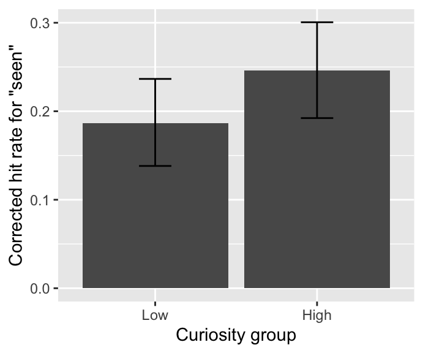

```
## Linear mixed-effects model fit by maximum likelihood
##  Data: outside.hit.rate.curiosity.group.median
##         AIC      BIC   logLik
##   -59.48359 -45.2669 35.74179
##
## Random effects:
##  Formula: ~1 + CurGrpMedian | SubjectNo
##  Structure: General positive-definite, Log-Cholesky parametrization
##                  StdDev     Corr
## (Intercept)      0.14585430 (Intr)
## CurGrpMedianHigh 0.13530260 -0.319
## Residual         0.06344866
##
## Fixed effects: SAcc ~ CurGrpMedian
##                       Value  Std.Error DF  t-value p-value
## (Intercept)      0.18652778 0.02547368 39 7.322373  0.0000
## CurGrpMedianHigh 0.05553052 0.02627996 38 2.113037  0.0412
##  Correlation:
##                  (Intr)
## CurGrpMedianHigh -0.396
##
## Standardized Within-Group Residuals:
##         Min          Q1         Med          Q3         Max
## -0.91326220 -0.33207910 -0.01669255  0.31306086  1.04690495
##
## Number of Observations: 79
## Number of Groups: 40
```

#### 3.4.2.1 Curiosity groups and temporal order of the objects

##### 3.4.2.1.1 Check the data

- **Is there any corrected hit rate < 0?**
  - There are 14 negative values out of a total of 164 values.

```
##     SubjectNo CurGrpMedian ObjOrdGrp     SFHit      SHit    SrcHit
##  1:       P18         High     Later 0.3333333 0.0000000 0.0000000
##  2:       P22         High     Early 0.1666667 0.0000000 0.0000000
##  3:       P22          Low     Later 0.1666667 0.0000000 0.0000000
##  4:       P23          Low     Later 0.2222222 0.1111111 0.1111111
##  5:       P28          Low     Later 0.2222222 0.0000000 0.1111111
##  6:       P30          Low     Later 0.3333333 0.0000000 0.1666667
##  7:       P31         High     Later 0.0000000 0.0000000 0.0000000
##  8:       P31         High     Early 0.2222222 0.0000000 0.0000000
##  9:       P35          Low     Early 0.5555556 0.0000000 0.1111111
## 10:       P35          Low     Later 0.4444444 0.0000000 0.2222222
## 11:       P36          Low     Later 0.4444444 0.1111111 0.2222222
## 12:       P39         High     Later 0.3333333 0.0000000 0.1666667
## 13:       P45         High     Later 0.4444444 0.1111111 0.1111111
## 14:       P50          Low     Later 0.2222222 0.0000000 0.1111111
##       SFFalse     SFalse   SrcFalse       SFAcc        SAcc      SrcAcc
##  1: 0.3888889 0.11111111 0.12962963 -0.05555556 -0.11111111 -0.12962963
##  2: 0.2222222 0.05555556 0.09259259 -0.05555556 -0.05555556 -0.09259259
##  3: 0.2222222 0.05555556 0.09259259 -0.05555556 -0.05555556 -0.09259259
##  4: 0.5000000 0.38888889 0.16666667 -0.27777778 -0.27777778 -0.05555556
##  5: 0.1111111 0.05555556 0.07407407  0.11111111 -0.05555556  0.03703704
##  6: 0.2777778 0.16666667 0.09259259  0.05555556 -0.16666667  0.07407407
##  7: 0.2222222 0.05555556 0.07407407 -0.22222222 -0.05555556 -0.07407407
##  8: 0.2222222 0.05555556 0.07407407  0.00000000 -0.05555556 -0.07407407
##  9: 0.5000000 0.05555556 0.16666667  0.05555556 -0.05555556 -0.05555556
## 10: 0.5000000 0.05555556 0.16666667 -0.05555556 -0.05555556  0.05555556
## 11: 0.5000000 0.27777778 0.16666667 -0.05555556 -0.16666667  0.05555556
## 12: 0.2777778 0.11111111 0.09259259  0.05555556 -0.11111111  0.07407407
## 13: 0.5555556 0.22222222 0.12962963 -0.11111111 -0.11111111 -0.01851852
## 14: 0.2777778 0.11111111 0.09259259 -0.05555556 -0.11111111  0.01851852
```

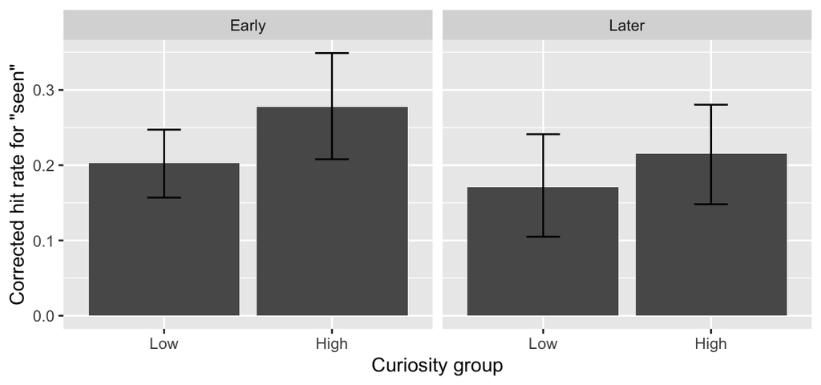

```
##    CurGrpMedian ObjOrdGrp      Mean        SD  N
## 1:         High     Early 0.2774929 0.2107490 39
## 2:          Low     Later 0.1705556 0.2273002 40
## 3:         High     Later 0.2148148 0.2080157 39
## 4:          Low     Early 0.2025000 0.1585884 40
```

```
##           Model df       AIC       BIC   logLik   Test  L.Ratio p-value
## baseline      1  8 -64.99094 -40.49018 40.49547
## ord.model     2  9 -66.29370 -38.73035 42.14685 1 vs 2 3.302763  0.0692
## cur.model     3 10 -68.64115 -38.01520 44.32057 2 vs 3 4.347446  0.0371
## int.model     4 11 -67.13772 -33.44917 44.56886 3 vs 4 0.496569  0.4810
```

```
## Linear mixed-effects model fit by maximum likelihood
##  Data: outside.hit.rate.item.order.curiosity.median
##         AIC      BIC   logLik
##   -68.64115 -38.0152 44.32057
##
## Random effects:
##  Formula: ~1 + CurGrpMedian + ObjOrdGrp | SubjectNo
##  Structure: General positive-definite, Log-Cholesky parametrization
##                  StdDev     Corr
## (Intercept)      0.11070730 (Intr) CrGrMH
## CurGrpMedianHigh 0.07424227 -0.097
## ObjOrdGrpLater   0.08516112  0.088  0.290
## Residual         0.14424057
##
## Fixed effects: SAcc ~ ObjOrdGrp + CurGrpMedian
##                        Value  Std.Error  DF   t-value p-value
## (Intercept)       0.21044754 0.02668115 116  7.887498  0.0000
## ObjOrdGrpLater   -0.04783952 0.02688162 116 -1.779637  0.0778
## CurGrpMedianHigh  0.05538022 0.02617152 116  2.116049  0.0365
##  Correlation:
##                  (Intr) ObjOGL
## ObjOrdGrpLater   -0.346
## CurGrpMedianHigh -0.409  0.068
##
## Standardized Within-Group Residuals:
##          Min           Q1          Med           Q3          Max
## -2.340969401 -0.628392858 -0.002142442  0.585140362  2.297032413
##
## Number of Observations: 158
## Number of Groups: 40
```

# 4 **Novelty** or **Curiosity**?

There are 35 negative values in a total of 236 values.

```
##     SubjectNo     Context    Group CurRating RoomOrder Duration     SFHit
##  1:       P15         Gym Familiar         4    Second       NA 0.5000000
##  2:       P15 StorageRoom    Novel         5     First       NA 0.3333333
##  3:       P18     Bedroom Familiar         2    Second       NA 0.6666667
##  4:       P18   Classroom Familiar         5    Second       NA 0.3333333
##  5:       P18  LivingRoom    Novel         7     First       NA 0.3333333
##  6:       P20   Classroom Familiar         4     First       NA 0.0000000
##  7:       P20     Library    Novel         2     First       NA 0.0000000
##  8:       P20 StorageRoom    Novel         6    Second       NA 0.1666667
##  9:       P22   Classroom    Novel         7    Second       NA 0.1666667
## 10:       P22     Library Familiar         2     First       NA 0.3333333
## 11:       P23     Library Familiar         4    Second       NA 0.5000000
## 12:       P23  LivingRoom Familiar         4    Second       NA 0.5000000
## 13:       P24     Bedroom    Novel         6    Second       NA 0.1666667
## 14:       P24     Library Familiar         2     First       NA 0.1666667
```

[output cut: 96 more lines]

## 4.1 For Curiosity group splitted by score (*Low*: 1 ~ 3; *High*: 5 ~ 7)

### 4.1.1 Curiosity first, novelty next

```
##               Model df       AIC       BIC   logLik   Test  L.Ratio
## base.model        1  8 -57.79591 -31.13416 36.89795
## cur.scr.model     2  9 -59.55589 -29.56142 38.77795 1 vs 2 3.759988
## nov.scr.model     3 10 -57.66273 -24.33554 38.83136 2 vs 3 0.106834
##               p-value
## base.model
## cur.scr.model  0.0525
## nov.scr.model  0.7438
```

```
## Linear mixed-effects model fit by maximum likelihood
##  Data: outside.hit.rate.per.room[!is.na(CurGrp)]
##         AIC       BIC   logLik
##   -59.55589 -29.56142 38.77795
##
## Random effects:
##  Formula: ~1 + CurGrp + Group | SubjectNo
##  Structure: General positive-definite, Log-Cholesky parametrization
##             StdDev      Corr
## (Intercept) 0.143696353 (Intr) CrGrpL
## CurGrpLow   0.113094952 -0.588
## GroupNovel  0.005633512  0.008 -0.026
## Residual    0.170622356
##
## Fixed effects: SAcc ~ CurGrp
##                   Value  Std.Error  DF  t-value p-value
## (Intercept)  0.23355900 0.02768021 166  8.43776  0.0000
## CurGrpLow   -0.06212908 0.03157768 166 -1.96750  0.0508
##  Correlation:
##           (Intr)
## CurGrpLow -0.564
##
## Standardized Within-Group Residuals:
##         Min          Q1         Med          Q3         Max
## -2.08486994 -0.58606354 -0.08928681  0.50908982  2.49069567
##
## Number of Observations: 207
## Number of Groups: 40
```

### 4.1.2 Novelty first, curiosity next

```
##               Model df       AIC       BIC   logLik   Test  L.Ratio
## base.model        1  8 -57.79591 -31.13416 36.89795
## nov.scr.model     2  9 -58.59735 -28.60289 38.29868 1 vs 2 2.801449
## cur.scr.model     3 10 -57.66273 -24.33554 38.83136 2 vs 3 1.065373
##               p-value
## base.model
## nov.scr.model  0.0942
## cur.scr.model  0.3020
```

```
## Linear mixed-effects model fit by maximum likelihood
##  Data: outside.hit.rate.per.room[!is.na(CurGrp)]
##         AIC       BIC   logLik
##   -58.59735 -28.60289 38.29868
##
## Random effects:
##  Formula: ~1 + CurGrp + Group | SubjectNo
##  Structure: General positive-definite, Log-Cholesky parametrization
##             StdDev      Corr
## (Intercept) 0.144266094 (Intr) CrGrpL
## CurGrpLow   0.116356395 -0.581
## GroupNovel  0.003527264 -0.001  0.015
## Residual    0.170624353
##
## Fixed effects: SAcc ~ Group
##                  Value  Std.Error  DF  t-value p-value
## (Intercept) 0.18091539 0.02641648 166 6.848581   0.000
## GroupNovel  0.04821956 0.02845001 166 1.694887   0.092
##  Correlation:
##            (Intr)
## GroupNovel -0.495
##
## Standardized Within-Group Residuals:
##         Min          Q1         Med          Q3         Max
## -2.11197873 -0.61552384 -0.07936849  0.46925113  2.42344899
##
## Number of Observations: 207
## Number of Groups: 40
```

## 4.2 For Curiosity group splitted by individual medians

### 4.2.1 Curiosity first, novelty next

```
##              Model df       AIC       BIC   logLik   Test  L.Ratio p-value
## base.model       1  8 -55.18414 -27.78454 35.59207
## cur.md.model     2  9 -57.53285 -26.70830 37.76642 1 vs 2 4.348708  0.0370
## nov.md.model     3 10 -55.26344 -21.01394 37.63172 2 vs 3 0.269404  0.6037
```

```
## Linear mixed-effects model fit by maximum likelihood
##  Data: outside.hit.rate.per.room[!is.na(CurGrpMedian)]
##         AIC      BIC   logLik
##   -57.53285 -26.7083 37.76642
##
## Random effects:
##  Formula: ~1 + CurGrpMedian + Group | SubjectNo
##  Structure: General positive-definite, Log-Cholesky parametrization
##                 StdDev     Corr
## (Intercept)     0.17773517 (Intr) CrGrML
## CurGrpMedianLow 0.09208976 -0.772
## GroupNovel      0.04099471 -0.943  0.699
## Residual        0.17916153
##
## Fixed effects: SAcc ~ CurGrpMedian
##                       Value  Std.Error  DF   t-value p-value
## (Intercept)      0.24404537 0.02828440 186  8.628266  0.0000
## CurGrpMedianLow -0.05810795 0.02665187 186 -2.180258  0.0305
##  Correlation:
##                 (Intr)
## CurGrpMedianLow -0.576
##
## Standardized Within-Group Residuals:
##         Min          Q1         Med          Q3         Max
## -2.14398012 -0.62560031 -0.04239434  0.61319532  2.50590155
##
## Number of Observations: 227
## Number of Groups: 40
```

### 4.2.2 Novelty first, curiosity next

```
##              Model df       AIC       BIC   logLik   Test  L.Ratio p-value
## base.model       1  8 -55.18414 -27.78454 35.59207
## nov.md.model     2  9 -56.62176 -25.79721 37.31088 1 vs 2 3.437624  0.0637
## cur.md.model     3 10 -55.26344 -21.01394 37.63172 2 vs 3 0.641680  0.4231
```

```
## Linear mixed-effects model fit by maximum likelihood
##  Data: outside.hit.rate.per.room[!is.na(CurGrpMedian)]
##         AIC       BIC   logLik
##   -56.62176 -25.79721 37.31088
##
## Random effects:
##  Formula: ~1 + CurGrpMedian + Group | SubjectNo
##  Structure: General positive-definite, Log-Cholesky parametrization
##                 StdDev     Corr
## (Intercept)     0.13930018 (Intr) CrGrML
## CurGrpMedianLow 0.07213381 -0.459
## GroupNovel      0.00661168  0.015  0.069
## Residual        0.17932319
##
## Fixed effects: SAcc ~ Group
##                  Value  Std.Error  DF  t-value p-value
## (Intercept) 0.18912533 0.02613613 186 7.236164   0.000
## GroupNovel  0.04994034 0.02618009 186 1.907569   0.058
##  Correlation:
##            (Intr)
## GroupNovel -0.441
##
## Standardized Within-Group Residuals:
##         Min          Q1         Med          Q3         Max
## -2.15820371 -0.61623338 -0.02337443  0.58486993  2.43765233
##
## Number of Observations: 227
## Number of Groups: 40
```